# Risk Factor Analysis

## Outcome Variable

**Outcome Variable:** whz

## Predictor Variables

**Intervention Variable:** predexfd6

**Adjustment Set:**

- arm
- sex
- brthmon
- W_mage
- meducyrs
- feducyrs
- hhwealth_quart
- hfoodsec
- W_mhtcm
- W_mwtkg
- W_mbmi
- vagbrth
- W_gagebrth
- W_birthwt
- W_birthlen
- W_nrooms
- W_nchldlt5
- month
- W_parity
- impfloor
- impsan
- safeh20
- delta_W_mage
- delta_meducyrs
- delta_feducyrs
- delta_hhwealth_quart
- delta_hfoodsec
- delta_W_mhtcm
- delta_W_mwtkg
- delta_W_mbmi
- delta_vagbrth
- delta_W_gagebrth
- delta_W_birthwt
- delta_W_birthlen
- delta_W_nrooms
- delta_W_nchldlt5
- delta_month
- delta_W_parity
- delta_impfloor
- delta_impsan
- delta_safeh20

## Stratifying Variables

The analysis was stratified on these variable(s):

- agecat
- studyid
- country

## Data Summary

| agecat | studyid | country | predexfd6 | n_cell | n |
| --- | --- | --- | --- | --- | --- |
| Birth | CMC-V-BCS-2002 | INDIA | 1 | 7 | 7 |
| Birth | CMC-V-BCS-2002 | INDIA | 0 | 0 | 7 |
| Birth | EE | PAKISTAN | 1 | 24 | 28 |
| Birth | EE | PAKISTAN | 0 | 4 | 28 |
| Birth | GMS-Nepal | NEPAL | 1 | 390 | 522 |
| Birth | GMS-Nepal | NEPAL | 0 | 132 | 522 |
| Birth | IRC | INDIA | 1 | 0 | 12 |
| Birth | IRC | INDIA | 0 | 12 | 12 |
| Birth | JiVitA-3 | BANGLADESH | 1 | 8392 | 10744 |
| Birth | JiVitA-3 | BANGLADESH | 0 | 2352 | 10744 |
| Birth | JiVitA-4 | BANGLADESH | 1 | 1802 | 2224 |
| Birth | JiVitA-4 | BANGLADESH | 0 | 422 | 2224 |
| Birth | Keneba | GAMBIA | 1 | 450 | 1327 |
| Birth | Keneba | GAMBIA | 0 | 877 | 1327 |
| Birth | MAL-ED | BANGLADESH | 1 | 68 | 194 |
| Birth | MAL-ED | BANGLADESH | 0 | 126 | 194 |
| Birth | MAL-ED | BRAZIL | 1 | 5 | 57 |
| Birth | MAL-ED | BRAZIL | 0 | 52 | 57 |
| Birth | MAL-ED | INDIA | 1 | 4 | 37 |
| Birth | MAL-ED | INDIA | 0 | 33 | 37 |
| Birth | MAL-ED | NEPAL | 1 | 3 | 23 |
| Birth | MAL-ED | NEPAL | 0 | 20 | 23 |
| Birth | MAL-ED | PERU | 1 | 72 | 208 |
| Birth | MAL-ED | PERU | 0 | 136 | 208 |
| Birth | MAL-ED | SOUTH AFRICA | 1 | 1 | 90 |
| Birth | MAL-ED | SOUTH AFRICA | 0 | 89 | 90 |
| Birth | MAL-ED | TANZANIA, UNITED REPUBLIC OF | 1 | 0 | 105 |
| Birth | MAL-ED | TANZANIA, UNITED REPUBLIC OF | 0 | 105 | 105 |
| Birth | PROVIDE | BANGLADESH | 1 | 155 | 532 |
| Birth | PROVIDE | BANGLADESH | 0 | 377 | 532 |

[output cut: 70 more lines]

The following strata were considered:

- agecat: 24 months, studyid: CMC-V-BCS-2002, country: INDIA
- agecat: 24 months, studyid: EE, country: PAKISTAN
- agecat: 24 months, studyid: GMS-Nepal, country: NEPAL
- agecat: 24 months, studyid: IRC, country: INDIA
- agecat: 24 months, studyid: JiVitA-3, country: BANGLADESH
- agecat: 24 months, studyid: JiVitA-4, country: BANGLADESH
- agecat: 24 months, studyid: Keneba, country: GAMBIA
- agecat: 24 months, studyid: LCNI-5, country: MALAWI
- agecat: 24 months, studyid: MAL-ED, country: BANGLADESH
- agecat: 24 months, studyid: MAL-ED, country: BRAZIL
- agecat: 24 months, studyid: MAL-ED, country: INDIA
- agecat: 24 months, studyid: MAL-ED, country: NEPAL
- agecat: 24 months, studyid: MAL-ED, country: PERU
- agecat: 24 months, studyid: MAL-ED, country: SOUTH AFRICA
- agecat: 24 months, studyid: MAL-ED, country: TANZANIA, UNITED REPUBLIC OF
- agecat: 24 months, studyid: PROVIDE, country: BANGLADESH
- agecat: 6 months, studyid: CMC-V-BCS-2002, country: INDIA
- agecat: 6 months, studyid: EE, country: PAKISTAN
- agecat: 6 months, studyid: GMS-Nepal, country: NEPAL
- agecat: 6 months, studyid: IRC, country: INDIA
- agecat: 6 months, studyid: JiVitA-3, country: BANGLADESH
- agecat: 6 months, studyid: JiVitA-4, country: BANGLADESH
- agecat: 6 months, studyid: Keneba, country: GAMBIA
- agecat: 6 months, studyid: LCNI-5, country: MALAWI
- agecat: 6 months, studyid: MAL-ED, country: BANGLADESH
- agecat: 6 months, studyid: MAL-ED, country: BRAZIL
- agecat: 6 months, studyid: MAL-ED, country: INDIA
- agecat: 6 months, studyid: MAL-ED, country: NEPAL
- agecat: 6 months, studyid: MAL-ED, country: PERU
- agecat: 6 months, studyid: MAL-ED, country: SOUTH AFRICA
- agecat: 6 months, studyid: MAL-ED, country: TANZANIA, UNITED REPUBLIC OF
- agecat: 6 months, studyid: PROVIDE, country: BANGLADESH
- agecat: 6 months, studyid: SAS-CompFeed, country: INDIA
- agecat: 6 months, studyid: SAS-FoodSuppl, country: INDIA
- agecat: Birth, studyid: CMC-V-BCS-2002, country: INDIA
- agecat: Birth, studyid: EE, country: PAKISTAN
- agecat: Birth, studyid: GMS-Nepal, country: NEPAL
- agecat: Birth, studyid: IRC, country: INDIA
- agecat: Birth, studyid: JiVitA-3, country: BANGLADESH
- agecat: Birth, studyid: JiVitA-4, country: BANGLADESH
- agecat: Birth, studyid: Keneba, country: GAMBIA
- agecat: Birth, studyid: MAL-ED, country: BANGLADESH
- agecat: Birth, studyid: MAL-ED, country: BRAZIL
- agecat: Birth, studyid: MAL-ED, country: INDIA
- agecat: Birth, studyid: MAL-ED, country: NEPAL
- agecat: Birth, studyid: MAL-ED, country: PERU
- agecat: Birth, studyid: MAL-ED, country: SOUTH AFRICA
- agecat: Birth, studyid: MAL-ED, country: TANZANIA, UNITED REPUBLIC OF
- agecat: Birth, studyid: PROVIDE, country: BANGLADESH
- agecat: Birth, studyid: SAS-CompFeed, country: INDIA

### Dropped Strata

Some strata were dropped due to rare outcomes:

- agecat: Birth, studyid: CMC-V-BCS-2002, country: INDIA
- agecat: Birth, studyid: EE, country: PAKISTAN
- agecat: Birth, studyid: IRC, country: INDIA
- agecat: Birth, studyid: MAL-ED, country: INDIA
- agecat: Birth, studyid: MAL-ED, country: NEPAL
- agecat: Birth, studyid: MAL-ED, country: SOUTH AFRICA
- agecat: Birth, studyid: MAL-ED, country: TANZANIA, UNITED REPUBLIC OF
- agecat: 6 months, studyid: CMC-V-BCS-2002, country: INDIA
- agecat: 6 months, studyid: IRC, country: INDIA
- agecat: 6 months, studyid: MAL-ED, country: SOUTH AFRICA
- agecat: 6 months, studyid: MAL-ED, country: TANZANIA, UNITED REPUBLIC OF
- agecat: 6 months, studyid: SAS-FoodSuppl, country: INDIA
- agecat: 24 months, studyid: CMC-V-BCS-2002, country: INDIA
- agecat: 24 months, studyid: EE, country: PAKISTAN
- agecat: 24 months, studyid: IRC, country: INDIA
- agecat: 24 months, studyid: MAL-ED, country: SOUTH AFRICA
- agecat: 24 months, studyid: MAL-ED, country: TANZANIA, UNITED REPUBLIC OF

## Methods Detail

We’re interested in the causal parameters $E[Y_a]$ for all values of $a \in \mathcal{A}$. These parameters represent the mean outcome if, possibly contrary to fact, we intervened to set all units to have $A=a$. Under the randomization and positivity assumptions, these are identified by the statistical parameters $\psi_a=E_W[E_{Y|A,W}(Y|A=a,W)]$. In addition, we’re interested in the mean of $Y$, $E[Y]$ under no intervention (the observed mean). We will estimate these parameters by using SuperLearner to fit the relevant likelihood factors – $E_{Y|A,W}(Y|A=a,W)$ and $p(A=a|W)$, and then updating our likelihood fit using a joint TMLE.

For unadjusted analyses ($W=\{\}$), initial likelihoods were estimated using Lrnr_glm to estimate the simple $E(Y|A)$ and Lrnr_mean to estimate $p(A)$. For adjusted analyses, a small library containing Lrnr_glmnet, Lrnr_xgboost, and Lrnr_mean was used.

Having estimated these parameters, we will then use the delta method to estimate relative risks and attributable risks relative to a prespecified baseline level of $A$.

# Results Detail

## Results Plots

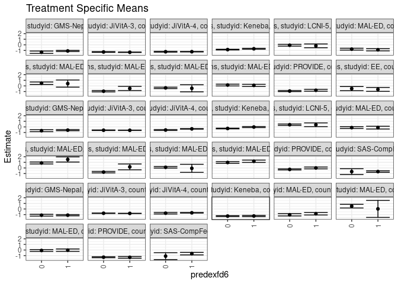

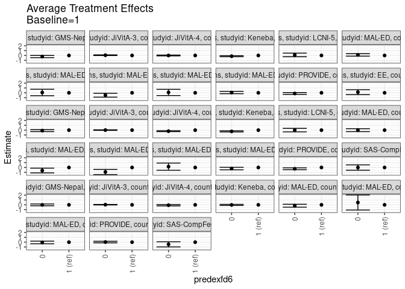

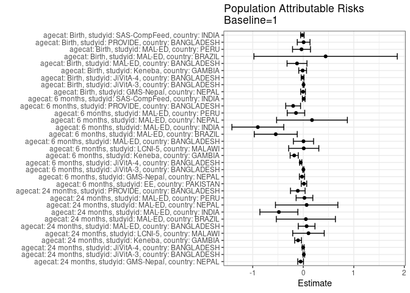

## Results Table

### Parameter: TSM

| agecat | studyid | country | intervention_level | baseline_level | estimate | ci_lower | ci_upper |
| --- | --- | --- | --- | --- | --- | --- | --- |
| Birth | GMS-Nepal | NEPAL | 1 | NA | -1.1020498 | -1.2150162 | -0.9890834 |
| Birth | GMS-Nepal | NEPAL | 0 | NA | -1.1075611 | -1.2676059 | -0.9475163 |
| Birth | JiVitA-3 | BANGLADESH | 1 | NA | -0.7865869 | -0.8113975 | -0.7617764 |
| Birth | JiVitA-3 | BANGLADESH | 0 | NA | -0.7597997 | -0.8035474 | -0.7160520 |
| Birth | JiVitA-4 | BANGLADESH | 1 | NA | -0.6769095 | -0.7318378 | -0.6219811 |
| Birth | JiVitA-4 | BANGLADESH | 0 | NA | -0.7469109 | -0.8832618 | -0.6105601 |
| Birth | Keneba | GAMBIA | 1 | NA | -1.2477289 | -1.3484049 | -1.1470529 |
| Birth | Keneba | GAMBIA | 0 | NA | -1.2649917 | -1.3415011 | -1.1884823 |
| Birth | MAL-ED | BANGLADESH | 1 | NA | -0.8519852 | -1.0697597 | -0.6342107 |
| Birth | MAL-ED | BANGLADESH | 0 | NA | -1.0339783 | -1.2412259 | -0.8267306 |
| Birth | MAL-ED | BRAZIL | 1 | NA | 0.0220000 | -1.4978207 | 1.5418207 |
| Birth | MAL-ED | BRAZIL | 0 | NA | 0.5069231 | 0.1803892 | 0.8334570 |
| Birth | MAL-ED | PERU | 1 | NA | -0.0242230 | -0.2373311 | 0.1888851 |
| Birth | MAL-ED | PERU | 0 | NA | -0.0788132 | -0.2422885 | 0.0846620 |
| Birth | PROVIDE | BANGLADESH | 1 | NA | -1.3061070 | -1.4585164 | -1.1536975 |
| Birth | PROVIDE | BANGLADESH | 0 | NA | -1.2800646 | -1.3694496 | -1.1906796 |
| Birth | SAS-CompFeed | INDIA | 1 | NA | -0.6419787 | -0.8661092 | -0.4178481 |
| Birth | SAS-CompFeed | INDIA | 0 | NA | -1.0901281 | -1.7027393 | -0.4775170 |
| 6 months | EE | PAKISTAN | 1 | NA | -0.6248062 | -0.9715960 | -0.2780164 |
| 6 months | EE | PAKISTAN | 0 | NA | -0.4893333 | -0.8590751 | -0.1195916 |
| 6 months | GMS-Nepal | NEPAL | 1 | NA | -0.5754049 | -0.6777827 | -0.4730271 |
| 6 months | GMS-Nepal | NEPAL | 0 | NA | -0.6711581 | -0.8418664 | -0.5004498 |
| 6 months | JiVitA-3 | BANGLADESH | 1 | NA | -0.6034118 | -0.6304813 | -0.5763424 |
| 6 months | JiVitA-3 | BANGLADESH | 0 | NA | -0.5908421 | -0.6366235 | -0.5450607 |
| 6 months | JiVitA-4 | BANGLADESH | 1 | NA | -0.3463032 | -0.3911355 | -0.3014709 |
| 6 months | JiVitA-4 | BANGLADESH | 0 | NA | -0.5538454 | -0.6346467 | -0.4730442 |
| 6 months | Keneba | GAMBIA | 1 | NA | -0.0207029 | -0.1187951 | 0.0773893 |
| 6 months | Keneba | GAMBIA | 0 | NA | -0.2796961 | -0.3422506 | -0.2171416 |
| 6 months | LCNI-5 | MALAWI | 1 | NA | 0.3829923 | 0.0484350 | 0.7175497 |
| 6 months | LCNI-5 | MALAWI | 0 | NA | 0.3944109 | 0.2674079 | 0.5214138 |
| 6 months | MAL-ED | BANGLADESH | 1 | NA | -0.1259328 | -0.3715961 | 0.1197305 |
| 6 months | MAL-ED | BANGLADESH | 0 | NA | -0.1251302 | -0.2901840 | 0.0399236 |
| 6 months | MAL-ED | BRAZIL | 1 | NA | 1.5163773 | 1.0555057 | 1.9772488 |
| 6 months | MAL-ED | BRAZIL | 0 | NA | 0.8872157 | 0.7130178 | 1.0614137 |
| 6 months | MAL-ED | INDIA | 1 | NA | 0.1922715 | -0.3255202 | 0.7100633 |
| 6 months | MAL-ED | INDIA | 0 | NA | -0.7423373 | -0.8758092 | -0.6088654 |
| 6 months | MAL-ED | NEPAL | 1 | NA | -0.0636646 | -0.7856909 | 0.6583617 |
| 6 months | MAL-ED | NEPAL | 0 | NA | 0.1136373 | -0.0252911 | 0.2525656 |
| 6 months | MAL-ED | PERU | 1 | NA | 1.1948911 | 0.9884895 | 1.4012927 |
| 6 months | MAL-ED | PERU | 0 | NA | 0.9762319 | 0.8221990 | 1.1302648 |
| 6 months | PROVIDE | BANGLADESH | 1 | NA | 0.0012336 | -0.1646240 | 0.1670912 |
| 6 months | PROVIDE | BANGLADESH | 0 | NA | -0.2624186 | -0.3572076 | -0.1676296 |
| 6 months | SAS-CompFeed | INDIA | 1 | NA | -0.6438016 | -0.7819173 | -0.5056859 |
| 6 months | SAS-CompFeed | INDIA | 0 | NA | -0.6500492 | -1.1672739 | -0.1328245 |
| 24 months | GMS-Nepal | NEPAL | 1 | NA | -1.0901008 | -1.1900401 | -0.9901615 |
| 24 months | GMS-Nepal | NEPAL | 0 | NA | -1.3147565 | -1.5235903 | -1.1059226 |
| 24 months | JiVitA-3 | BANGLADESH | 1 | NA | -1.3217251 | -1.3564797 | -1.2869705 |
| 24 months | JiVitA-3 | BANGLADESH | 0 | NA | -1.2721196 | -1.3349759 | -1.2092632 |
| 24 months | JiVitA-4 | BANGLADESH | 1 | NA | -1.2244845 | -1.2651004 | -1.1838686 |
| 24 months | JiVitA-4 | BANGLADESH | 0 | NA | -1.2297365 | -1.3066103 | -1.1528627 |
| 24 months | Keneba | GAMBIA | 1 | NA | -0.7010253 | -0.7833270 | -0.6187236 |
| 24 months | Keneba | GAMBIA | 0 | NA | -0.8510843 | -0.9124807 | -0.7896880 |
| 24 months | LCNI-5 | MALAWI | 1 | NA | -0.1804846 | -0.5146919 | 0.1537227 |
| 24 months | LCNI-5 | MALAWI | 0 | NA | -0.0693589 | -0.2302953 | 0.0915775 |
| 24 months | MAL-ED | BANGLADESH | 1 | NA | -0.8837117 | -1.0757074 | -0.6917161 |
| 24 months | MAL-ED | BANGLADESH | 0 | NA | -0.7686166 | -0.9315479 | -0.6056853 |
| 24 months | MAL-ED | BRAZIL | 1 | NA | 0.4108069 | -0.2238581 | 1.0454719 |
| 24 months | MAL-ED | BRAZIL | 0 | NA | 0.4765102 | 0.2555094 | 0.6975110 |
| 24 months | MAL-ED | INDIA | 1 | NA | -0.4616676 | -0.8378802 | -0.0854550 |
| 24 months | MAL-ED | INDIA | 0 | NA | -0.9562633 | -1.0806812 | -0.8318455 |
| 24 months | MAL-ED | NEPAL | 1 | NA | -0.4348095 | -1.0675311 | 0.1979121 |
| 24 months | MAL-ED | NEPAL | 0 | NA | -0.3601052 | -0.4809721 | -0.2392383 |
| 24 months | MAL-ED | PERU | 1 | NA | 0.0872868 | -0.1053198 | 0.2798934 |
| 24 months | MAL-ED | PERU | 0 | NA | 0.1449856 | -0.0090949 | 0.2990661 |
| 24 months | PROVIDE | BANGLADESH | 1 | NA | -0.7849196 | -0.9496479 | -0.6201913 |
| 24 months | PROVIDE | BANGLADESH | 0 | NA | -0.9222902 | -1.0171779 | -0.8274024 |

### Parameter: E(Y)

| agecat | studyid | country | intervention_level | baseline_level | estimate | ci_lower | ci_upper |
| --- | --- | --- | --- | --- | --- | --- | --- |
| Birth | GMS-Nepal | NEPAL | NA | NA | -1.1064559 | -1.2034951 | -1.0094168 |
| Birth | JiVitA-3 | BANGLADESH | NA | NA | -0.7807809 | -0.8030521 | -0.7585097 |
| Birth | JiVitA-4 | BANGLADESH | NA | NA | -0.6904586 | -0.7435822 | -0.6373351 |
| Birth | Keneba | GAMBIA | NA | NA | -1.2599925 | -1.3251703 | -1.1948146 |
| Birth | MAL-ED | BANGLADESH | NA | NA | -0.9755670 | -1.1287016 | -0.8224325 |
| Birth | MAL-ED | BRAZIL | NA | NA | 0.4643860 | 0.1360519 | 0.7927200 |
| Birth | MAL-ED | PERU | NA | NA | -0.0587981 | -0.1871869 | 0.0695908 |
| Birth | PROVIDE | BANGLADESH | NA | NA | -1.2984586 | -1.3752758 | -1.2216415 |
| Birth | SAS-CompFeed | INDIA | NA | NA | -0.6596308 | -0.9005716 | -0.4186900 |
| 6 months | EE | PAKISTAN | NA | NA | -0.6106944 | -0.9239621 | -0.2974268 |
| 6 months | GMS-Nepal | NEPAL | NA | NA | -0.6009171 | -0.6886356 | -0.5131986 |
| 6 months | JiVitA-3 | BANGLADESH | NA | NA | -0.6001300 | -0.6240378 | -0.5762223 |
| 6 months | JiVitA-4 | BANGLADESH | NA | NA | -0.3968456 | -0.4358721 | -0.3578192 |
| 6 months | Keneba | GAMBIA | NA | NA | -0.1997647 | -0.2531388 | -0.1463906 |
| 6 months | LCNI-5 | MALAWI | NA | NA | 0.3925000 | 0.2735307 | 0.5114693 |
| 6 months | MAL-ED | BANGLADESH | NA | NA | -0.1213203 | -0.2539388 | 0.0112981 |
| 6 months | MAL-ED | BRAZIL | NA | NA | 0.9720774 | 0.8078144 | 1.1363403 |
| 6 months | MAL-ED | INDIA | NA | NA | -0.7067317 | -0.8369134 | -0.5765499 |
| 6 months | MAL-ED | NEPAL | NA | NA | 0.1091407 | -0.0265536 | 0.2448351 |
| 6 months | MAL-ED | PERU | NA | NA | 1.0506150 | 0.9281868 | 1.1730433 |
| 6 months | PROVIDE | BANGLADESH | NA | NA | -0.1990907 | -0.2817968 | -0.1163845 |
| 6 months | SAS-CompFeed | INDIA | NA | NA | -0.6348861 | -0.7630511 | -0.5067211 |
| 24 months | GMS-Nepal | NEPAL | NA | NA | -1.1423525 | -1.2336321 | -1.0510729 |
| 24 months | JiVitA-3 | BANGLADESH | NA | NA | -1.3103375 | -1.3408810 | -1.2797940 |
| 24 months | JiVitA-4 | BANGLADESH | NA | NA | -1.2265320 | -1.2620508 | -1.1910132 |
| 24 months | Keneba | GAMBIA | NA | NA | -0.8032329 | -0.8532842 | -0.7531817 |
| 24 months | LCNI-5 | MALAWI | NA | NA | -0.0770652 | -0.2204213 | 0.0662909 |
| 24 months | MAL-ED | BANGLADESH | NA | NA | -0.8169756 | -0.9388013 | -0.6951499 |
| 24 months | MAL-ED | BRAZIL | NA | NA | 0.4626233 | 0.2567495 | 0.6684971 |
| 24 months | MAL-ED | INDIA | NA | NA | -0.9442584 | -1.0642426 | -0.8242742 |
| 24 months | MAL-ED | NEPAL | NA | NA | -0.3674429 | -0.4840752 | -0.2508107 |
| 24 months | MAL-ED | PERU | NA | NA | 0.1111982 | -0.0118399 | 0.2342362 |
| 24 months | PROVIDE | BANGLADESH | NA | NA | -0.8928670 | -0.9755153 | -0.8102187 |

### Parameter: ATE

| agecat | studyid | country | intervention_level | baseline_level | estimate | ci_lower | ci_upper |
| --- | --- | --- | --- | --- | --- | --- | --- |
| Birth | GMS-Nepal | NEPAL | 1 | 1 | 0.0000000 | 0.0000000 | 0.0000000 |
| Birth | GMS-Nepal | NEPAL | 0 | 1 | -0.0055113 | -0.1918024 | 0.1807798 |
| Birth | JiVitA-3 | BANGLADESH | 1 | 1 | 0.0000000 | 0.0000000 | 0.0000000 |
| Birth | JiVitA-3 | BANGLADESH | 0 | 1 | 0.0267872 | -0.0217097 | 0.0752842 |
| Birth | JiVitA-4 | BANGLADESH | 1 | 1 | 0.0000000 | 0.0000000 | 0.0000000 |
| Birth | JiVitA-4 | BANGLADESH | 0 | 1 | -0.0700015 | -0.2134888 | 0.0734859 |
| Birth | Keneba | GAMBIA | 1 | 1 | 0.0000000 | 0.0000000 | 0.0000000 |
| Birth | Keneba | GAMBIA | 0 | 1 | -0.0172628 | -0.1333484 | 0.0988228 |
| Birth | MAL-ED | BANGLADESH | 1 | 1 | 0.0000000 | 0.0000000 | 0.0000000 |
| Birth | MAL-ED | BANGLADESH | 0 | 1 | -0.1819930 | -0.4860912 | 0.1221051 |
| Birth | MAL-ED | BRAZIL | 1 | 1 | 0.0000000 | 0.0000000 | 0.0000000 |
| Birth | MAL-ED | BRAZIL | 0 | 1 | 0.4849231 | -1.0695798 | 2.0394260 |
| Birth | MAL-ED | PERU | 1 | 1 | 0.0000000 | 0.0000000 | 0.0000000 |
| Birth | MAL-ED | PERU | 0 | 1 | -0.0545902 | -0.3244432 | 0.2152629 |
| Birth | PROVIDE | BANGLADESH | 1 | 1 | 0.0000000 | 0.0000000 | 0.0000000 |
| Birth | PROVIDE | BANGLADESH | 0 | 1 | 0.0260424 | -0.1432289 | 0.1953138 |
| Birth | SAS-CompFeed | INDIA | 1 | 1 | 0.0000000 | 0.0000000 | 0.0000000 |
| Birth | SAS-CompFeed | INDIA | 0 | 1 | -0.4481495 | -0.9783681 | 0.0820692 |
| 6 months | EE | PAKISTAN | 1 | 1 | 0.0000000 | 0.0000000 | 0.0000000 |
| 6 months | EE | PAKISTAN | 0 | 1 | 0.1354729 | -0.3714513 | 0.6423970 |
| 6 months | GMS-Nepal | NEPAL | 1 | 1 | 0.0000000 | 0.0000000 | 0.0000000 |
| 6 months | GMS-Nepal | NEPAL | 0 | 1 | -0.0957532 | -0.2948868 | 0.1033804 |
| 6 months | JiVitA-3 | BANGLADESH | 1 | 1 | 0.0000000 | 0.0000000 | 0.0000000 |
| 6 months | JiVitA-3 | BANGLADESH | 0 | 1 | 0.0125697 | -0.0392644 | 0.0644039 |
| 6 months | JiVitA-4 | BANGLADESH | 1 | 1 | 0.0000000 | 0.0000000 | 0.0000000 |
| 6 months | JiVitA-4 | BANGLADESH | 0 | 1 | -0.2075423 | -0.2997609 | -0.1153236 |
| 6 months | Keneba | GAMBIA | 1 | 1 | 0.0000000 | 0.0000000 | 0.0000000 |
| 6 months | Keneba | GAMBIA | 0 | 1 | -0.2589932 | -0.3745832 | -0.1434032 |
| 6 months | LCNI-5 | MALAWI | 1 | 1 | 0.0000000 | 0.0000000 | 0.0000000 |
| 6 months | LCNI-5 | MALAWI | 0 | 1 | 0.0114185 | -0.3466665 | 0.3695036 |
| 6 months | MAL-ED | BANGLADESH | 1 | 1 | 0.0000000 | 0.0000000 | 0.0000000 |
| 6 months | MAL-ED | BANGLADESH | 0 | 1 | 0.0008026 | -0.2965791 | 0.2981843 |
| 6 months | MAL-ED | BRAZIL | 1 | 1 | 0.0000000 | 0.0000000 | 0.0000000 |
| 6 months | MAL-ED | BRAZIL | 0 | 1 | -0.6291615 | -1.1208724 | -0.1374507 |
| 6 months | MAL-ED | INDIA | 1 | 1 | 0.0000000 | 0.0000000 | 0.0000000 |
| 6 months | MAL-ED | INDIA | 0 | 1 | -0.9346088 | -1.4697875 | -0.3994302 |
| 6 months | MAL-ED | NEPAL | 1 | 1 | 0.0000000 | 0.0000000 | 0.0000000 |
| 6 months | MAL-ED | NEPAL | 0 | 1 | 0.1773019 | -0.5585335 | 0.9131373 |
| 6 months | MAL-ED | PERU | 1 | 1 | 0.0000000 | 0.0000000 | 0.0000000 |
| 6 months | MAL-ED | PERU | 0 | 1 | -0.2186592 | -0.4793695 | 0.0420512 |
| 6 months | PROVIDE | BANGLADESH | 1 | 1 | 0.0000000 | 0.0000000 | 0.0000000 |
| 6 months | PROVIDE | BANGLADESH | 0 | 1 | -0.2636522 | -0.4548460 | -0.0724584 |
| 6 months | SAS-CompFeed | INDIA | 1 | 1 | 0.0000000 | 0.0000000 | 0.0000000 |
| 6 months | SAS-CompFeed | INDIA | 0 | 1 | -0.0062476 | -0.5560776 | 0.5435824 |
| 24 months | GMS-Nepal | NEPAL | 1 | 1 | 0.0000000 | 0.0000000 | 0.0000000 |
| 24 months | GMS-Nepal | NEPAL | 0 | 1 | -0.2246557 | -0.4562159 | 0.0069046 |
| 24 months | JiVitA-3 | BANGLADESH | 1 | 1 | 0.0000000 | 0.0000000 | 0.0000000 |
| 24 months | JiVitA-3 | BANGLADESH | 0 | 1 | 0.0496055 | -0.0218398 | 0.1210508 |
| 24 months | JiVitA-4 | BANGLADESH | 1 | 1 | 0.0000000 | 0.0000000 | 0.0000000 |
| 24 months | JiVitA-4 | BANGLADESH | 0 | 1 | -0.0052520 | -0.0900266 | 0.0795225 |
| 24 months | Keneba | GAMBIA | 1 | 1 | 0.0000000 | 0.0000000 | 0.0000000 |
| 24 months | Keneba | GAMBIA | 0 | 1 | -0.1500591 | -0.2513959 | -0.0487222 |
| 24 months | LCNI-5 | MALAWI | 1 | 1 | 0.0000000 | 0.0000000 | 0.0000000 |
| 24 months | LCNI-5 | MALAWI | 0 | 1 | 0.1111257 | -0.2598925 | 0.4821439 |
| 24 months | MAL-ED | BANGLADESH | 1 | 1 | 0.0000000 | 0.0000000 | 0.0000000 |
| 24 months | MAL-ED | BANGLADESH | 0 | 1 | 0.1150952 | -0.1406668 | 0.3708571 |
| 24 months | MAL-ED | BRAZIL | 1 | 1 | 0.0000000 | 0.0000000 | 0.0000000 |
| 24 months | MAL-ED | BRAZIL | 0 | 1 | 0.0657033 | -0.6052055 | 0.7366122 |
| 24 months | MAL-ED | INDIA | 1 | 1 | 0.0000000 | 0.0000000 | 0.0000000 |
| 24 months | MAL-ED | INDIA | 0 | 1 | -0.4945957 | -0.8901719 | -0.0990195 |
| 24 months | MAL-ED | NEPAL | 1 | 1 | 0.0000000 | 0.0000000 | 0.0000000 |
| 24 months | MAL-ED | NEPAL | 0 | 1 | 0.0747043 | -0.5688947 | 0.7183033 |
| 24 months | MAL-ED | PERU | 1 | 1 | 0.0000000 | 0.0000000 | 0.0000000 |
| 24 months | MAL-ED | PERU | 0 | 1 | 0.0576987 | -0.1874119 | 0.3028093 |
| 24 months | PROVIDE | BANGLADESH | 1 | 1 | 0.0000000 | 0.0000000 | 0.0000000 |
| 24 months | PROVIDE | BANGLADESH | 0 | 1 | -0.1373706 | -0.3264960 | 0.0517548 |

### Parameter: PAR

| agecat | studyid | country | intervention_level | baseline_level | estimate | ci_lower | ci_upper |
| --- | --- | --- | --- | --- | --- | --- | --- |
| Birth | GMS-Nepal | NEPAL | 1 | NA | -0.0044061 | -0.0513027 | 0.0424905 |
| Birth | JiVitA-3 | BANGLADESH | 1 | NA | 0.0058060 | -0.0047993 | 0.0164114 |
| Birth | JiVitA-4 | BANGLADESH | 1 | NA | -0.0135492 | -0.0411307 | 0.0140324 |
| Birth | Keneba | GAMBIA | 1 | NA | -0.0122636 | -0.0896250 | 0.0650979 |
| Birth | MAL-ED | BANGLADESH | 1 | NA | -0.1235818 | -0.3205858 | 0.0734222 |
| Birth | MAL-ED | BRAZIL | 1 | NA | 0.4423860 | -0.9762121 | 1.8609840 |
| Birth | MAL-ED | PERU | 1 | NA | -0.0345750 | -0.2121363 | 0.1429863 |
| Birth | PROVIDE | BANGLADESH | 1 | NA | 0.0076483 | -0.1182697 | 0.1335664 |
| Birth | SAS-CompFeed | INDIA | 1 | NA | -0.0176521 | -0.0527130 | 0.0174088 |
| 6 months | EE | PAKISTAN | 1 | NA | 0.0141118 | -0.0400020 | 0.0682256 |
| 6 months | GMS-Nepal | NEPAL | 1 | NA | -0.0255122 | -0.0768476 | 0.0258232 |
| 6 months | JiVitA-3 | BANGLADESH | 1 | NA | 0.0032818 | -0.0085460 | 0.0151096 |
| 6 months | JiVitA-4 | BANGLADESH | 1 | NA | -0.0505424 | -0.0718293 | -0.0292556 |
| 6 months | Keneba | GAMBIA | 1 | NA | -0.1790618 | -0.2597041 | -0.0984194 |
| 6 months | LCNI-5 | MALAWI | 1 | NA | 0.0095077 | -0.2886912 | 0.3077066 |
| 6 months | MAL-ED | BANGLADESH | 1 | NA | 0.0046124 | -0.1951545 | 0.2043793 |
| 6 months | MAL-ED | BRAZIL | 1 | NA | -0.5442999 | -0.9696217 | -0.1189781 |
| 6 months | MAL-ED | INDIA | 1 | NA | -0.8990032 | -1.4124163 | -0.3855901 |
| 6 months | MAL-ED | NEPAL | 1 | NA | 0.1728054 | -0.5277037 | 0.8733144 |
| 6 months | MAL-ED | PERU | 1 | NA | -0.1442761 | -0.3175743 | 0.0290221 |
| 6 months | PROVIDE | BANGLADESH | 1 | NA | -0.2003243 | -0.3472394 | -0.0534092 |
| 6 months | SAS-CompFeed | INDIA | 1 | NA | 0.0089155 | -0.0178262 | 0.0356572 |
| 24 months | GMS-Nepal | NEPAL | 1 | NA | -0.0522517 | -0.1089747 | 0.0044713 |
| 24 months | JiVitA-3 | BANGLADESH | 1 | NA | 0.0113876 | -0.0048905 | 0.0276657 |
| 24 months | JiVitA-4 | BANGLADESH | 1 | NA | -0.0020475 | -0.0210191 | 0.0169240 |
| 24 months | Keneba | GAMBIA | 1 | NA | -0.1022077 | -0.1693126 | -0.0351027 |
| 24 months | LCNI-5 | MALAWI | 1 | NA | 0.1034194 | -0.2084972 | 0.4153360 |
| 24 months | MAL-ED | BANGLADESH | 1 | NA | 0.0667361 | -0.0986281 | 0.2321003 |
| 24 months | MAL-ED | BRAZIL | 1 | NA | 0.0518164 | -0.5329696 | 0.6366023 |
| 24 months | MAL-ED | INDIA | 1 | NA | -0.4825908 | -0.8585168 | -0.1066648 |
| 24 months | MAL-ED | NEPAL | 1 | NA | 0.0673666 | -0.5501057 | 0.6848389 |
| 24 months | MAL-ED | PERU | 1 | NA | 0.0239114 | -0.1410807 | 0.1889034 |
| 24 months | PROVIDE | BANGLADESH | 1 | NA | -0.1079474 | -0.2524759 | 0.0365810 |